# Linear Regression Model - Student GPA Score

Piotr Wieczorek

2024-04-10

```r
rm(list=ls())
```

### Libraries

```r
library(tidyverse)
library(scales)
library(ggthemr)
library(skimr)
library(olsrr)
library(moments)
library(car)
library(patchwork)
```

### Reading and exploring the data

```r
df <- read.csv("satgpa.csv")
```

### Explaining variables:

1. sat_v Verbal SAT percentile.
2. sat_m Math SAT percentile.
3. sat_sum Total of verbal and math SAT percentiles.
4. hs_gpa High school grade point average.
5. fy_gpa First year (college) grade point average.

```r
head(df)
```

```
##   sex sat_v sat_m sat_sum hs_gpa fy_gpa
## 1   1    65    62     127   3.40   3.18
## 2   2    58    64     122   4.00   3.33
## 3   2    56    60     116   3.75   3.25
## 4   1    42    53      95   3.75   2.42
## 5   1    55    52     107   4.00   2.63
## 6   2    55    56     111   4.00   2.91
```

##### Setting up theme

```r
ggthemr(palette="dust")
```

```r
th <- theme(strip.text = element_text(size=12),
        axis.text.x = element_text(size=12),
        axis.text.y=element_text(size=12),
        plot.title = element_text(size=14))
```

### Relationship between student scores and gender

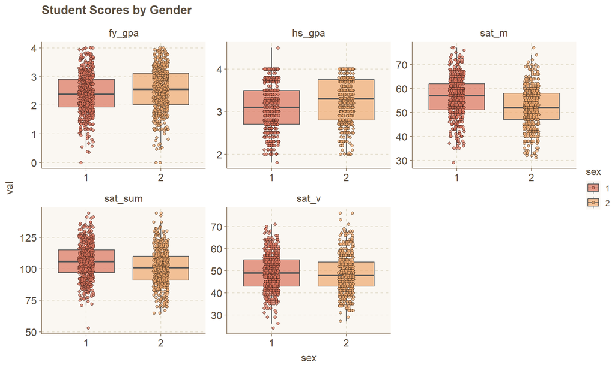

```r
df %>%
  mutate(sex=as.factor(sex)) %>%
  gather(c(2:6), value = "val",key="key") %>%
  ggplot(aes(x=sex,y=val,fill=sex)) +
  geom_boxplot(outlier.shape = NA,alpha=0.7) +
  geom_jitter(shape=21,position = position_jitter(width=0.1),alpha=0.7,color="black") +
  facet_wrap(~key,scales="free") +
  labs(title="Student Scores by Gender") + th
```

### Relationship between fy_gpa and other variabless

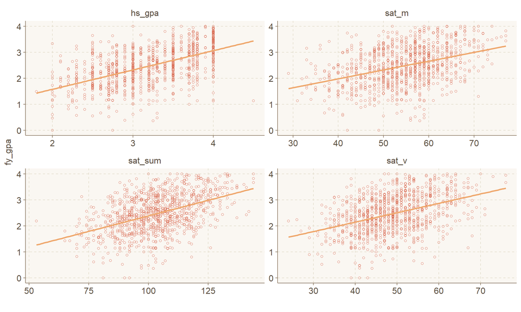

```r
df %>%
  gather(c(2:5),value="val",key="key") %>%
  ggplot(aes(x=val,y=fy_gpa)) +
  geom_point(alpha=1,shape=21) +
  geom_smooth(method="lm",se=F)+
  facet_wrap(~key,scales="free")+
  labs(x="")+
  th
```

```r
swatch()
```

```
## [1] "#555555" "#db735c" "#EFA86E" "#9A8A76" "#F3C57B" "#7A6752" "#2A91A2"
## [8] "#87F28A" "#6EDCEF"
## attr(,"class")
## [1] "ggthemr_swatch"
```

```r
ggthemr("dust")
```

### Exploring fy_gpa distribution

##### The distribution is skewed to the left (mean is lower than median)

##### Kurtosis is below 3, indicating less residuals (shorter tails) than in a theoretical normal distribution. The distribution is also flatter and more spread out around the mean

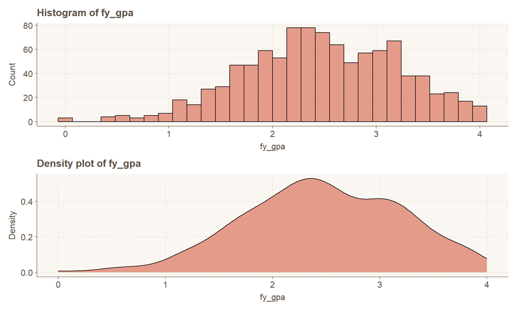

```r
p1 <- df %>%
  ggplot(aes(x=fy_gpa)) +
  geom_histogram(color="black",alpha=0.7) +
  labs(y="Count",title="Histogram of fy_gpa")+
  th

p2 <- df %>%
  ggplot(aes(x=fy_gpa)) +
  geom_density(color="black",fill="#db735c",alpha=0.7) +
  labs(title="Density plot of fy_gpa",y="Density")+
  th

p1/p2
```

```r
print(paste("Skewness:",round(skewness(df$fy_gpa),4)))
```

```
## [1] "Skewness: -0.2161"
```

```r
print(paste("Kurtosis:",round(kurtosis(df$fy_gpa),4)))
```

```
## [1] "Kurtosis: 2.8053"
```

## Modeling the data

### First model

```r
mod1<- lm(data=df,formula = fy_gpa ~. -sat_sum)
```

```r
summary(mod1)
```

```
##
## Call:
## lm(formula = fy_gpa ~ . - sat_sum, data = df)
##
## Residuals:
##     Min      1Q  Median      3Q     Max
## -2.0601 -0.3478  0.0315  0.4106  1.7042
##
## Coefficients:
##              Estimate Std. Error t value Pr(>|t|)
## (Intercept) -1.118836   0.164539  -6.800 1.80e-11 ***
## sex          0.141837   0.040077   3.539  0.00042 ***
## sat_v        0.016133   0.002635   6.123 1.32e-09 ***
## sat_m        0.015513   0.002732   5.678 1.78e-08 ***
## hs_gpa       0.545008   0.039505  13.796  < 2e-16 ***
## ---
## Signif. codes:  0 '***' 0.001 '**' 0.01 '*' 0.05 '.' 0.1 ' ' 1
##
## Residual standard error: 0.5908 on 995 degrees of freedom
## Multiple R-squared:  0.3666, Adjusted R-squared:  0.364
## F-statistic:   144 on 4 and 995 DF,  p-value: < 2.2e-16
```

#### Residual vs Fitted Values plot

##### There is no relationship between residuals and fitted values

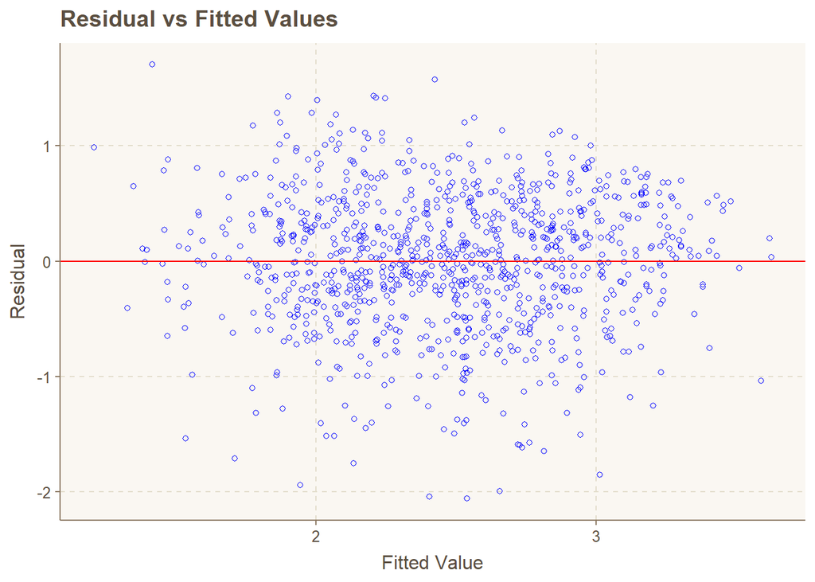

```r
olsrr::ols_plot_resid_fit(mod1)
```

#### Durbin Watson test

##### Based on p-value > 0.05, there is no autocorrelation of first order in the residuals

```r
car::durbinWatsonTest(mod1)
```

```
##  lag Autocorrelation D-W Statistic p-value
##    1    -0.005325322      2.009913    0.87
##  Alternative hypothesis: rho != 0
```

#### VIF (Variance Inflation Factor)

##### None of the variables exhibit higher values than 5, which means that the independent variables don’t explain each other well (they are no collinearity between them)

```r
vif(mod1)
```

```
##      sex    sat_v    sat_m   hs_gpa
## 1.149380 1.347200 1.525464 1.310603
```

#### Cook’s distance

##### There are some influential data points which will be investigated upon

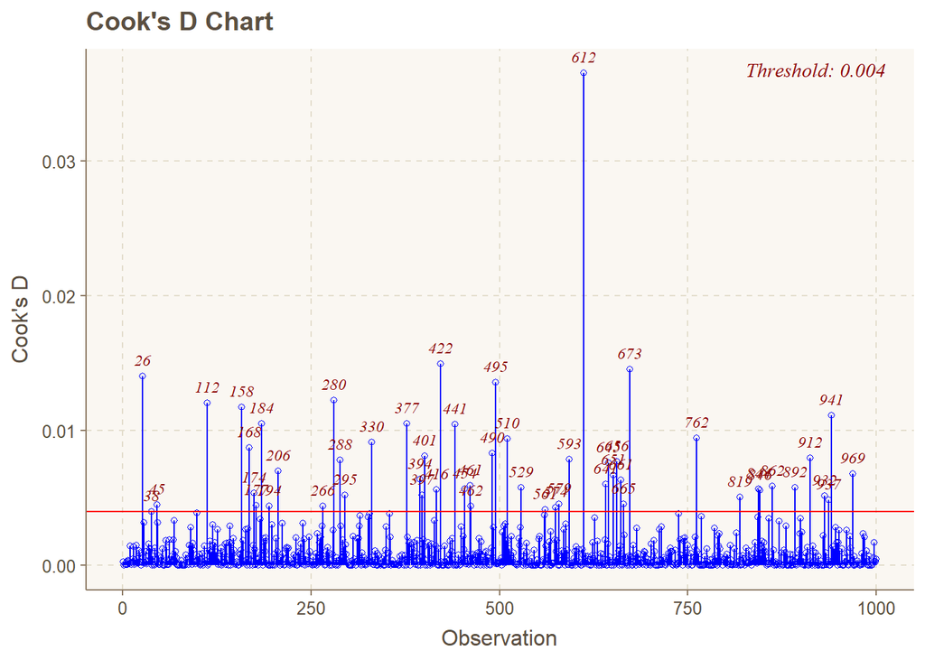

```r
ols_plot_cooksd_chart(mod1)
```

```r
round(4/(1000-4-1),3) #4/(N−k−1) <- formula for Cook's Distance Threshold
```

```
## [1] 0.004
```

#### Getting influential data points indexes

```r
cooks_indexes <- which(cooks.distance(mod1) > 0.004)
```

```r
cooks_indexes
```

```
##  26  38  45 112 158 168 174 177 184 194 206 266 280 288 295 330 377 394 397 401
##  26  38  45 112 158 168 174 177 184 194 206 266 280 288 295 330 377 394 397 401
## 416 422 441 454 461 462 490 495 510 529 561 574 579 593 612 641 645 651 656 661
## 416 422 441 454 461 462 490 495 510 529 561 574 579 593 612 641 645 651 656 661
## 665 673 762 819 844 846 862 892 912 932 937 941 969
## 665 673 762 819 844 846 862 892 912 932 937 941 969
```

#### Summary of data containing only influential data points

```r
summary(df[cooks_indexes,2:6])
```

```
##      sat_v           sat_m          sat_sum        hs_gpa          fy_gpa
##  Min.   :24.00   Min.   :29.00   Min.   : 53   Min.   :2.000   Min.   :0.000
##  1st Qu.:41.00   1st Qu.:47.00   1st Qu.: 90   1st Qu.:2.500   1st Qu.:0.770
##  Median :47.00   Median :54.00   Median :103   Median :2.900   Median :1.300
##  Mean   :47.94   Mean   :53.02   Mean   :101   Mean   :3.006   Mean   :1.724
##  3rd Qu.:56.00   3rd Qu.:59.00   3rd Qu.:110   3rd Qu.:3.600   3rd Qu.:3.100
##  Max.   :68.00   Max.   :74.00   Max.   :142   Max.   :4.500   Max.   :4.000
```

#### Sumary of data excluding influential values

```r
summary(df[-cooks_indexes,2:6])
```

```
##      sat_v           sat_m          sat_sum          hs_gpa          fy_gpa
##  Min.   :26.00   Min.   :31.00   Min.   : 65.0   Min.   :1.800   Min.   :0.57
##  1st Qu.:43.00   1st Qu.:49.00   1st Qu.: 93.0   1st Qu.:2.800   1st Qu.:2.02
##  Median :49.00   Median :55.00   Median :103.0   Median :3.200   Median :2.48
##  Mean   :48.99   Mean   :54.47   Mean   :103.5   Mean   :3.209   Mean   :2.51
##  3rd Qu.:54.00   3rd Qu.:60.00   3rd Qu.:113.0   3rd Qu.:3.700   3rd Qu.:3.02
##  Max.   :76.00   Max.   :77.00   Max.   :144.0   Max.   :4.000   Max.   :4.00
```

### Second model (without influential data points)

```r
mod2<- lm(data=df[-cooks_indexes,],formula = fy_gpa ~. -sat_sum)
```

##### R^2 is higher than in the first model, indicating that mod2 captures (explains) more variance in the dependent variable

```r
summary(mod2)
```

```
##
## Call:
## lm(formula = fy_gpa ~ . - sat_sum, data = df[-cooks_indexes,
##     ])
##
## Residuals:
##     Min      1Q  Median      3Q     Max
## -1.6292 -0.3216  0.0054  0.3701  1.4083
##
## Coefficients:
##              Estimate Std. Error t value Pr(>|t|)
## (Intercept) -1.179122   0.147125  -8.014 3.26e-15 ***
## sex          0.163606   0.036098   4.532 6.59e-06 ***
## sat_v        0.014499   0.002400   6.042 2.19e-09 ***
## sat_m        0.016448   0.002527   6.510 1.22e-10 ***
## hs_gpa       0.573325   0.036269  15.807  < 2e-16 ***
## ---
## Signif. codes:  0 '***' 0.001 '**' 0.01 '*' 0.05 '.' 0.1 ' ' 1
##
## Residual standard error: 0.5087 on 942 degrees of freedom
## Multiple R-squared:  0.4478, Adjusted R-squared:  0.4454
## F-statistic:   191 on 4 and 942 DF,  p-value: < 2.2e-16
```

#### Residual vs Fitted Values plot

##### There is no relationship between residuals and fitted values

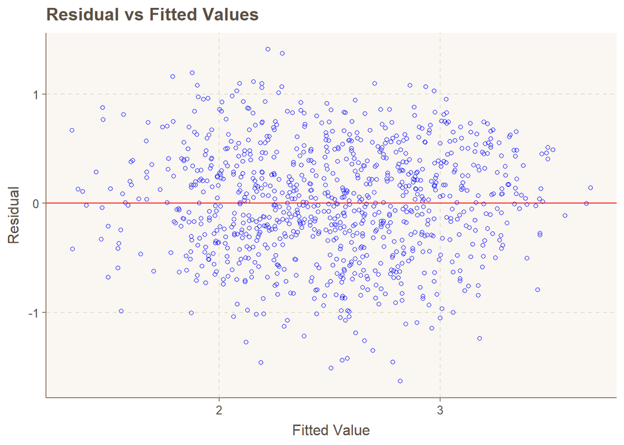

```r
olsrr::ols_plot_resid_fit(mod2)
```

#### VIF (Variance Inflation Factor)

##### None of the variables exhibit higher values than 5, which means that the independent variables don’t explain each other well (they are no collinearity between them)

```r
vif(mod2)
```

```
##      sex    sat_v    sat_m   hs_gpa
## 1.191043 1.386378 1.625132 1.360203
```

#### Durbin Watson test

##### Based on p-value > 0.05, there is no autocorrelation of first order in the residuals

```r
car::durbinWatsonTest(mod2)
```

```
##  lag Autocorrelation D-W Statistic p-value
##    1      0.01587313      1.967222   0.592
##  Alternative hypothesis: rho != 0
```